# An Overview of Asian-American Quality-of-Life Predictors

Author

Miles Dostert, James Le, Nhi Luong

Published

May 12, 2025

# Introduction

Literature on this topic provides a diverse list of factors that influence Asian-American Quality of Life (AAQoL). A Pew Research Center study found that the majority of Asian immigrants in the U.S. (77%) believe that their standard of living is higher than their parents’, but under half (48%) think their children’s standard of living will be better than theirs (Tian et al., 2024). For U.S.-born Asian adults, these proportions drop to 60% and 29%, respectively. (Tian et al., 2024). This illustrates the importance of birthplace in influencing quality of life. In Hawaii, studies have found that multi-ethnic Asian-Americans reported higher satisfaction with both mental and physical health compared to their mono-ethnic counterparts in some way (Zhang, 2011). One possible explanation for such a discrepancy is that multi-ethnic individuals have to navigate complex social networks, which bring more social benefits and increased fulfillment. Meanwhile, a different study has found that young Asian-Americans are isolated from their families due to their unmarried status (Jang et al., 2021). Additionally, middle-aged Asian-Americans from 40 to 59 years old have the highest odds of being socially isolated due to their limited English proficiency (Jang et al., 2021). This trend is worth noting as social isolation has been considered a health risk factor comparable to smoking 15 cigarettes a day (Holt-Lunstad et al., 2015). Moreover, limited English proficiency also plays a role in Asian-Americans’ lower participation in health services (Jang & Kim, 2018), which could potentially delay and complicate underlying health conditions, especially with avoidance of treatment and regular check-ups. These references complicate an already-complex argument and will be crucial in providing a more objective and all-encompassing assessment of quality of life for our interpretation.

.

# Material & Method

We utilize a dataset from “The Final Report on the Asian American Quality of Life”, located on the data.austintexas.gov website, the official City of Austin data portal. The report was submitted in October 2016 under the lead of Dr. Yuri Jang from the University of Texas at Austin School of Social Work. This data derives from large-scale paper surveys distributed to Asian-American residents of Austin, Texas, through 76 survey sessions across 891 survey sites selected based on the Austin Asian Community Resource Database from August to December, 2015. They include city public centers, educational facilities, medical establishments, religious institutions, local businesses (such as restaurants and grocery stores), and other social services providers. Notably, Asian-Americans are defined in the report as “individuals having origins in any of the original peoples of the Far East, Southeast Asia, or the Indian subcontinent” aged 18 and above. It took about 20 min for each participant to complete the questionnaire, and respondents were each paid U.S. $10 for their participation. The dataset included 2609 unique observations and 231 variables covering many diverse topics. Some are picked from existing national and state surveys, including information on demographics, immigration and acculturation, health, emotional wellbeing, special interests, social and community resources, and general living conditions in Austin. They were collected in Texas as this state displays the highest U.S. growth rate for Asian-American populations, with a 72.4% increase from 2000 to 2010 (City of Austin, Texas, 2018). Austin also currently houses an estimated 110,000 to 115,000 Asian residents, second only to Houston, Texas (City of Austin, Texas, 2018). Our dataset highlights an ever-increasing population, and while our findings may not apply to other states with slower growth rates, they will prove pertinent in recognizing patterns, as the proportion of Asian-Americans in the United States is projected to increase from 5.6% to 10% by 2050 (City of Austin, Texas, 2018).

# Results

Table 1: Categorical Variables Summary Statistics

| Variables | **Missing values** | **N = 2,565**<sup>1</sup> |
| --- | --- | --- |
| Ethnicity | 0 |  |
| Asian Indian |  | 568 (22%) |
| Chinese |  | 630 (25%) |
| Filipino |  | 262 (10%) |
| Korean |  | 467 (18%) |
| Other |  | 143 (5.6%) |
| Vietnamese |  | 495 (19%) |
| Marital Status | 13 |  |
| Living with a partner |  | 102 (4.0%) |
| Married |  | 1,704 (67%) |
| Other |  | 29 (1.1%) |
| Single |  | 717 (28%) |
| Income (US dollars) | 187 |  |
| under70k |  | 1,390 (58%) |
| over70k |  | 988 (42%) |
| Present Mental Health | 9 |  |
| Excellent |  | 630 (25%) |
| Fair |  | 190 (7.4%) |
| Good |  | 720 (28%) |
| Poor |  | 28 (1.1%) |
| Very Good |  | 988 (39%) |
| English Difficulties | 31 |  |
| Much |  | 541 (21%) |
| Not at all |  | 765 (30%) |
| Not much |  | 723 (29%) |
| Very much |  | 505 (20%) |

<sup>1</sup> n (%)

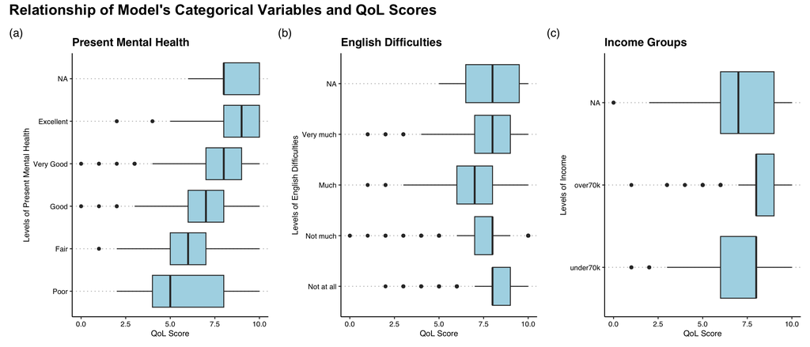

As shown in Figure 1(a), there are five levels of Present Mental Health indicate the self-reported response of participants about their state of mental health. The median of the QoL score increases as the positivity of the levels increases. In Figure 1(b), there are four levels of English Difficulties. Participants in lower levels of English Difficulties (“Not at all”, “Not much”) have higher median QoL score than level “Much”. However, level “Very much” has higher median QoL score than that of level Much. In Figure 1(c), there are two levels of Income Groups with level “under70k” a collapse of seven levels of income range. The medians of two groups are the same at 8, but level ‘under70k’ has a larger IQR than that of level ‘over70k’

Table 2: Numerical Variables Summary Statistics

| Variables | **Missing values** | **N = 2,565**<sup>1</sup> |
| --- | --- | --- |
| Quality of life (Scale of 1-10) | 0 | 7.67 ± 1.63 |
| Age (years) | 4 | 43 ± 17 |
| Household size (persons) | 11 | 3.29 ± 1.47 |
| Duration of residency (years) | 36 | 16 ± 13 |
| Education completed (years) | 31 | 15.11 ± 2.41 |

<sup>1</sup> Mean ± SD

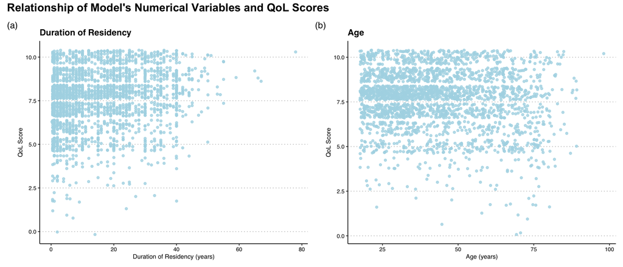

Table 3: Predictors of Quality of Life (Transformed)

|  | MLR Model (Transformed) Coefficients | MLR Model (Transformed) p-value | MLR Model (Transformed) Lower Bound | MLR Model (Transformed) Upper Bound |
| --- | --- | --- | --- | --- |
| Age | 0.998** | 0.007 | 0.997 | 0.999 |
| Income over $70,000 | 1.189*** | 0 | 1.143 | 1.236 |
| Mental health (Fair) | 0.516*** | 0 | 0.474 | 0.561 |
| Mental health (Good) | 0.62*** | 0 | 0.587 | 0.654 |
| Mental health (Poor) | 0.519*** | 0 | 0.43 | 0.626 |
| Mental health (Very Good) | 0.739*** | 0 | 0.704 | 0.776 |
| Duration of residency | 1.006*** | 0 | 1.004 | 1.008 |
| English difficulties (Not at all) | 1.167*** | 0 | 1.101 | 1.236 |
| English difficulties (Not much) | 1.011 | 0.696 | 0.957 | 1.068 |
| English difficulties (Very much) | 1.05 | 0.115 | 0.988 | 1.116 |
| Num.Obs. | 2258 |  |  |  |
| R2 Adj. | 0.265 |  |  |  |